# Reproducing analyses from the NICE Evidence Synthesis Technical Support Documents in MetaInsight v1.0

Tom Morris (tm428@leicester.ac.uk)

July 2024

[figure not shown]

[figure not shown]

For comments or questions on MetaInsight please e-mail apps@crsu.org.uk.

# 1 Introduction

This guide contains step-by-step instructions to reproduce the example meta-analyses in the NICE Evidence Synthesis Technical Support Documents [(https://www.sheffield.ac.uk/nice-dsu/tsds/evidence-synthesis)](https://www.sheffield.ac.uk/nice-dsu/tsds/evidence-synthesis), using the MetaInsight app [(https://crsu.shinyapps.io/MetaInsight/)](https://crsu.shinyapps.io/MetaInsight/). Six of the examples contained in TSD2 and TSD3 can be carried out in MetaInsight, though three of these are pairwise meta-analyses and are not included in this guide. Before starting, the reader should familiarise themselves with the example(s) they wish to reproduce and download the accompanying WinBUGS files.

There are eight examples in TSD2 and six in TSD3, of which there is one network meta-analysis in TSD2 and two network meta-regressions in TSD3 that can be reproduced in MetaInsight. These are:

**TSD2 Examples**

| Example | Model | In MetaInsight |
| --- | --- | --- |
| TSD2 Example 1, Blocker | Binomial, logit (pairwise) | Yes (not shown) |
| TSD2 Example 2, Dietary fat | Binomial, cloglog | No |
| TSD2 Example 3, Diabetes | Poisson, log | No |
| TSD2 Example 4, Schizophrenia | Multinomial, log | No |
| TSD2 Example 5 Parkinson’s | Normal, identity | Yes |
| TSD2 Example 6 Psoriasis | Conditional Binomial, probit | No |
| TSD2 Example 7 Parkinson’s difference | Normal, identity, contrasts | No |
| TSD2 Example 8 Parkinson’s shared | Normal, identity, shared | No |

**TSD3 Examples**

| Example | Model | In MetaInsight |
| --- | --- | --- |
| TSD3 Example 1, Magnesium | Binomial, logit, cross-validation (pairwise) | No |
| TSD3 Example 2, Chemotherapy | Binomial, logit, cross-validation | No |
| TSD3 Example 3, Statins | Binomial, logit, binary meta-regression (pairwise) | Yes (not shown) |
| TSD3 Example 4, BCG vaccine | Binomial, logit, continuous meta-regression (pairwise) | Yes (not shown) |
| TSD3 Example 5, Certolizumab | Binomial, logit, continuous meta-regression | Yes |
| TSD3 Example 6, Certolizumab | Binomial, logit, baseline risk | Yes |

# 2 TSD2 Example 5, Parkinsons

## 2.1 Create the dataset

The WinBUGS files are *TSD2-5aRE_Normal_id.odc* and *TSD2-5bFE_Normal_id.odc*. The data in the two files are the same, so only one needs to be opened. The file can be opened in WinBUGS (not OpenBUGS) or another text editor. Copy the data as shown below.

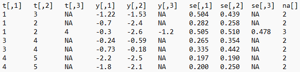

Paste the data into a spreadsheet, possibly using a paste special to maintain the column and row structure.

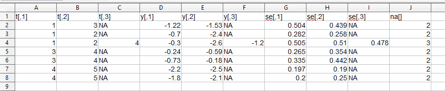

The data format corresponds to *Wide format* in MetaInsight.

Rename the first six columns to **T.1**, **T.2**, **T.3**, **Mean.1**, **Mean.2**, and **Mean.3** respectively, delete the **na[ ]** column, and add a column called **Study** with distinct entries that consist of letters, numbers and underscores only. The **Study** and **T** columns should not consist entirely of numbers, so change the treatments to contain letters, for example change “1” to “Treat1”.

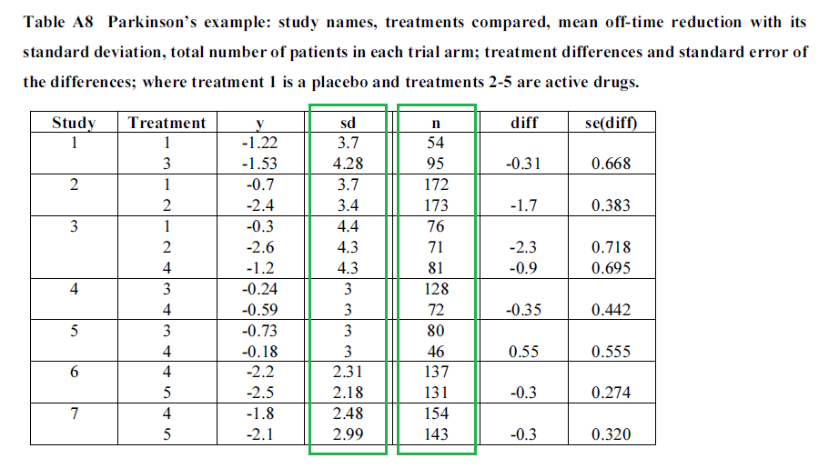

The final dataset should look like this.

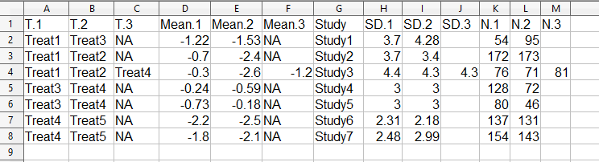

Depending on the type of spreadsheet used, the data may now be ready to upload to MetaInsight. If a problem occurs then saving the file as a *CSV* should fix it.

## 2.2 Analyse the data

Open MetaInsight and navigate to the *Load Data* tab.

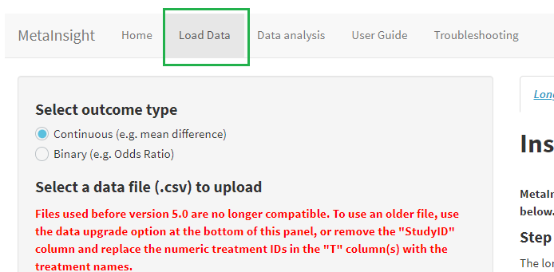

**Continuous** outcome type should already be selected.

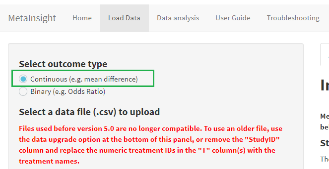

Upload the dataset, check that **Treat1** is selected as the reference treatment, and view the data by selecting the **View Data** tab.

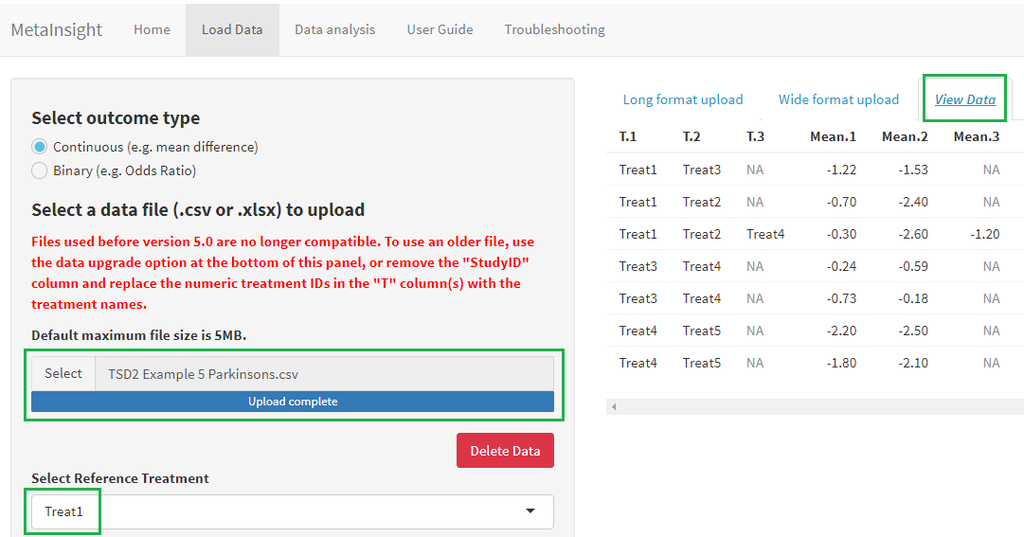

Navigate to the **Data Analysis** tab.

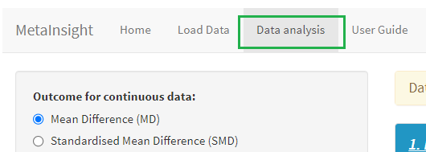

Select the required model options. This example uses **Mean Difference**, smaller outcome values are **Desirable**, and there is output from both a fixed effects and a random effects model, so either of these can be chosen.

[figure not shown]

Within the Data Analysis tab navigate to the **Bayesian network meta-analysis** tab.

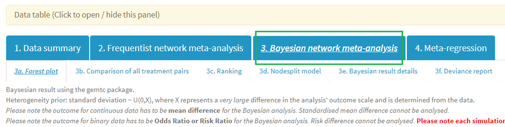

Click the **Click here to run the main analysis for all studies** button.

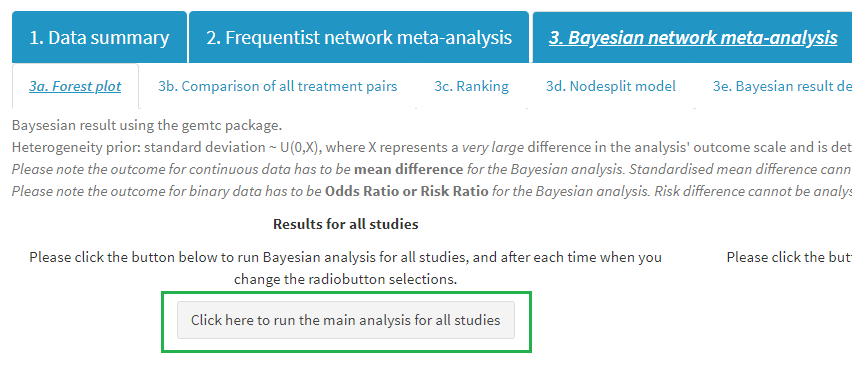

## 2.3 Compare the results

The results from WinBUGS are shown in Table A9 on page 82 of the TSD2 pdf file:

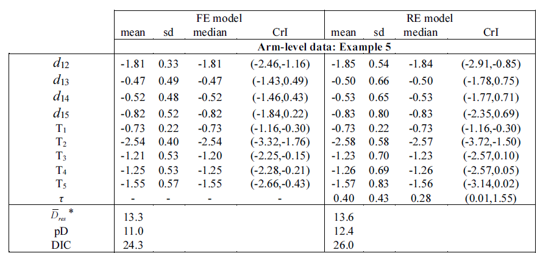

The relative treatment effects $d_{12}$, …, $d_{15}$ and their 95% credible intervals are displayed in the forest plot in MetaInsight. The one below is from the random effects model.

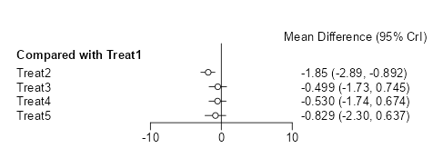

The medians and standard deviations of the relative treatment effects are sometimes available in the **Bayesian result details** tab, as they are in this example. The underlying R package that creates the model, {gemtc}, sometimes parameterises the model in such a way that these statistics are not available for all relative treatment effects.

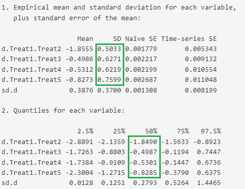

The absolute treatment effects $T_1$, …, $T_5$ are not provided by MetaInsight.

$\overline{D}_{res}$, $p_D$, and $DIC$ are all provided underneath the forest plot. The mean of $\tau$ and its 95% credible interval can also be found there for the random effects model. The median and standard deviation of $\tau$ can be found in the **Bayesian result details** tab in the **sd.d** rows (above).

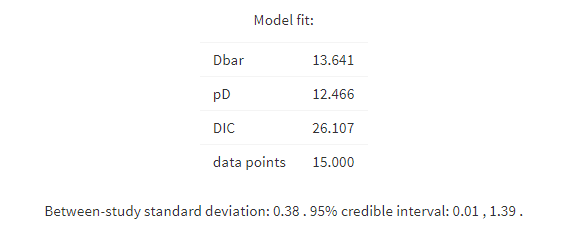

# 3 TSD3 Example 5, Certolizumab: continuous covariate

## 3.1 Create the dataset

The WinBUGS files are *TSD3-4aRE_continuousCZP.odc* and *TSD3-4bFE_continuousCZP*. The data in the two files are the same, so only one needs to be opened. The file can be opened in WinBUGS (not OpenBUGS) or another text editor. Copy the data as shown below.

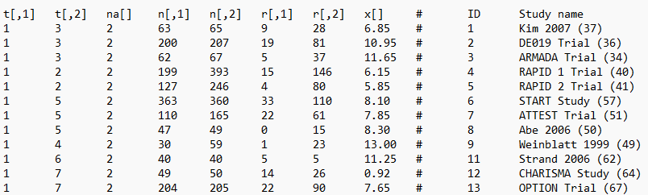

Paste the data into a spreadsheet, possibly using a paste special to maintain the column and row structure.

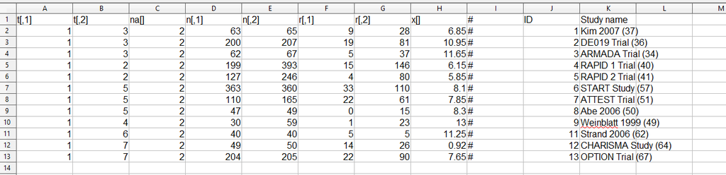

The data format corresponds to *Wide format* in MetaInsight.

Delete the **na[]**, **#** and **ID** columns and rename the remaining columns respectively to **T.1**, **T.2**, **N.1**, **N.2**, **R.1**, **R.2**, **covar.x**, and **Study**. Add letters to the **T** columns (e.g. change “1” to “Treat1”) and delete any characters from **Study** that are not letters, numbers or underscores.

The final dataset should look like this.

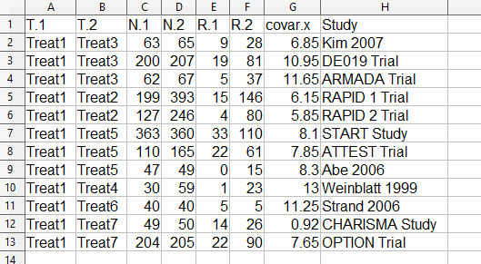

Depending on the type of spreadsheet used, the data may now be ready to upload to MetaInsight. If a problem occurs then saving the file as a *CSV* should fix it.

## 3.2 Analyse the data

Open MetaInsight, navigate to the **Load Data** tab and select **Binary** outcome type.

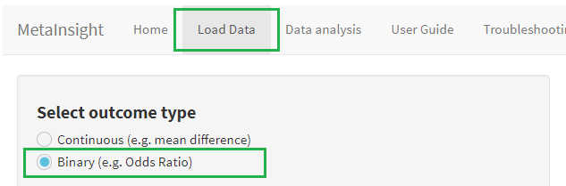

Upload the dataset, check that **Treat1** is selected as the reference treatment, and view the data by selecting the **View Data** tab.

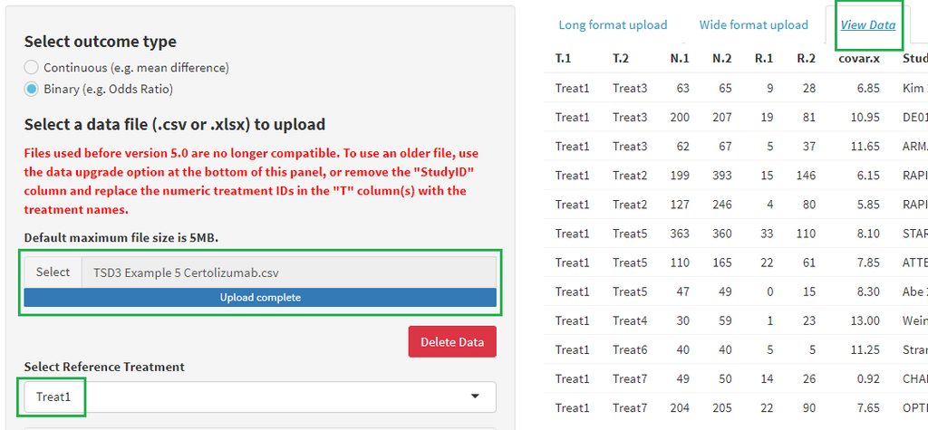

Navigate to the **Data Analysis** tab.

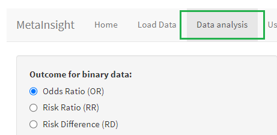

Select the required model options. This example uses **Odds Ratio**, smaller outcome values are **Undesirable**, and there is output from both a fixed effects and a random effects model, so either of these can be chosen.

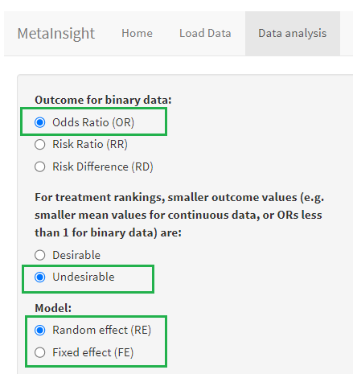

Within the Data Analysis tab navigate to the **Meta-regression** tab and then the **Covariate Analysis** tab.

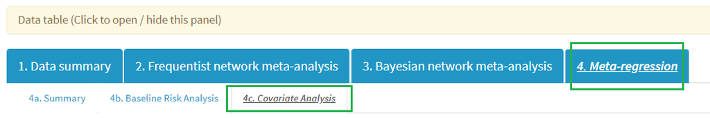

Leave the regression coefficient at the default *shared* and click the **Click here to run the main analysis for all studies** button.

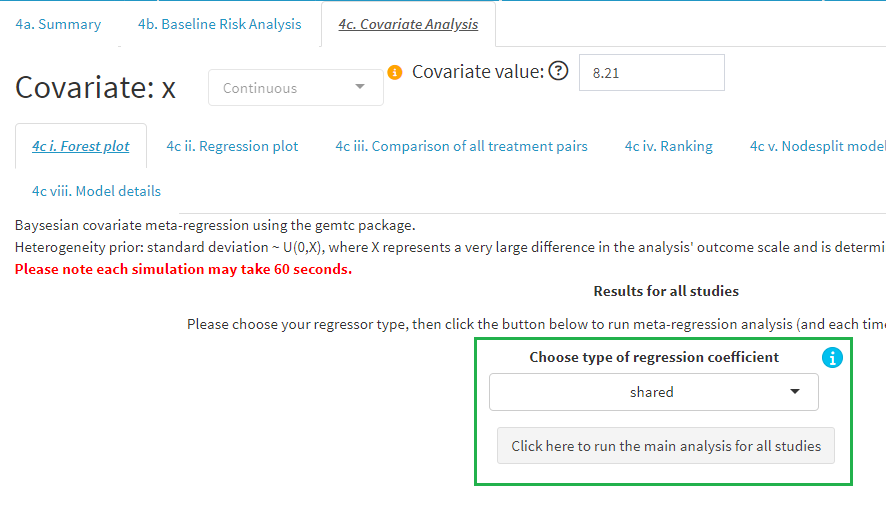

## 3.3 Compare the results

The results from WinBUGS are shown in Table 7 on page 41 of the TSD3 pdf file:

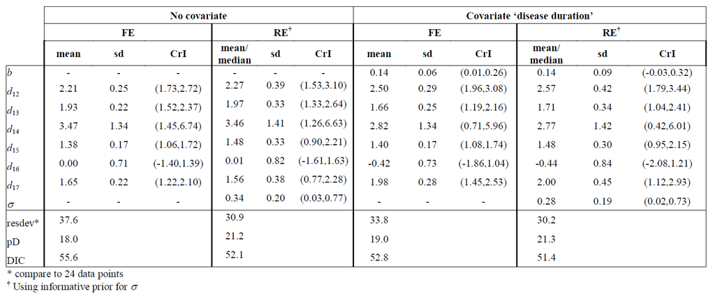

The relative treatment effects $d_{12}$, …, $d_{17}$ and their 95% credible intervals (on the odds ratio scale) are displayed in the forest plot in MetaInsight. The one below is from the random effects model.

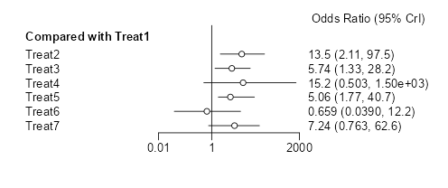

The medians and standard deviations of the relative treatment effects are in the **Bayesian result details** tab.

Also in this tab are statistics on the shared regression parameter $b$. This parameter is not the same as the parameter $B$ in MetaInsight, and so their statistics cannot be directly compared. In MetaInsight the covariate values are scaled to have standard deviation 0.5, whereas in WinBUGS they are not. The scaling factor in this example is approximately 6.5, and it can be seen that the medians differ by approximately this factor.

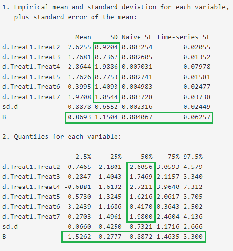

$resdev$ ($Dbar$ in MetaInsight) , $p_D$, and $DIC$ are all provided underneath the forest plot. The mean of $\sigma$ and its 95% credible interval can also be found there for the random effects model. The median and standard deviation of $\sigma$ can be found in the **Bayesian result details** tab in the **sd.d** rows (above).

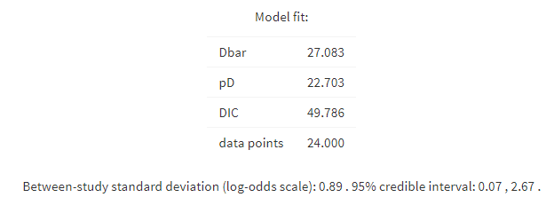

A plot showing the regression lines is on page 39 of TSD3:

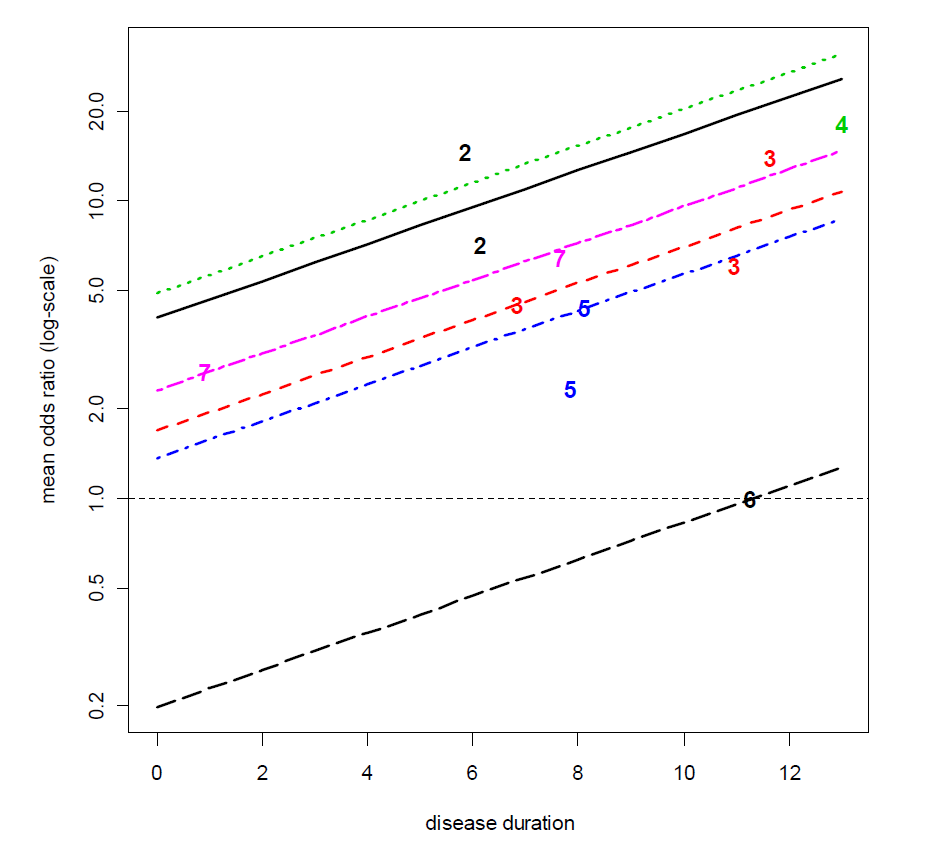

This is the equivalent plot in MetaInsight, which also displays study contributions and confidence regions:

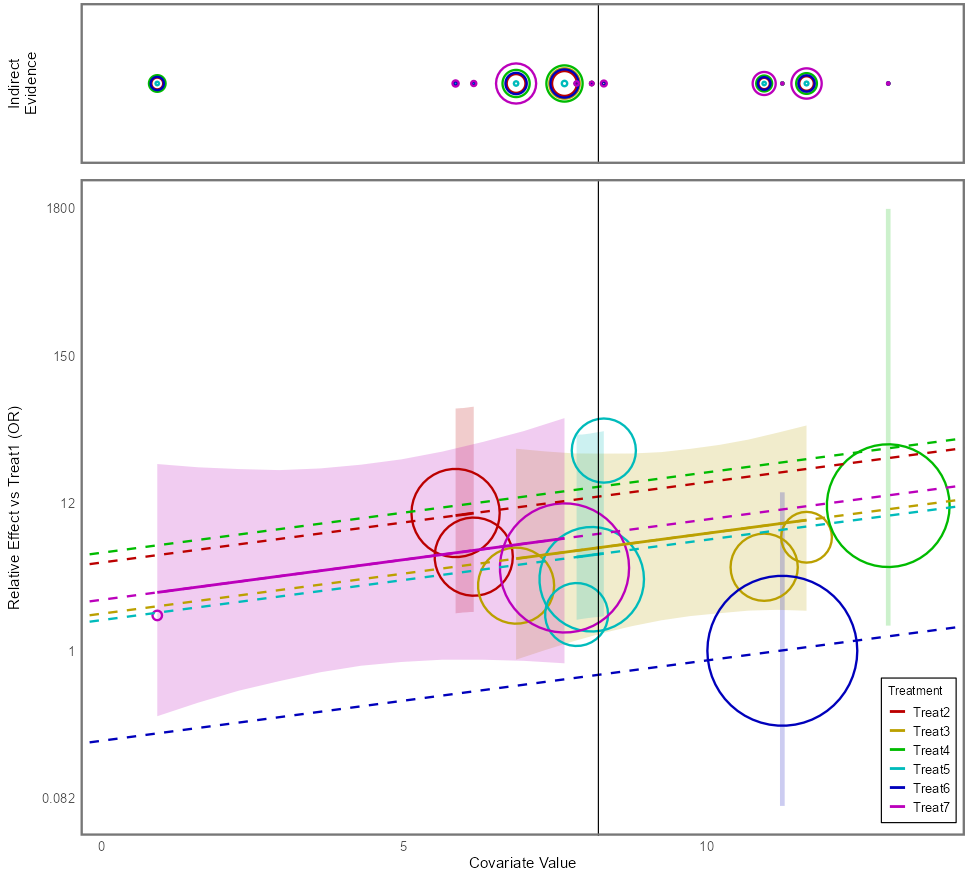